# 3 3. Exploratory Analysis

#### 3.3.0.2 6.2 Residuals vs Fitted Plot

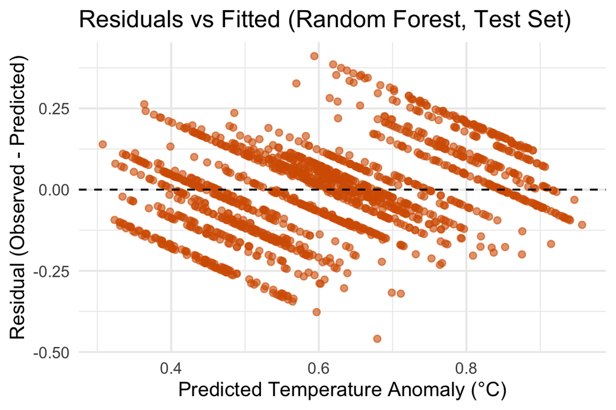

```r
# 4. Residuals vs Fitted (Test set)

test$rf_resid <- test$temp_anomaly - test$rf_pred

p2 <- ggplot(test, aes(x = rf_pred, y = rf_resid)) +
  geom_point(alpha = 0.6, color = "#D55E00") +
  geom_hline(yintercept = 0, linetype = "dashed") +
  labs(
    title = "Residuals vs Fitted (Random Forest, Test Set)",
    x = "Predicted Temperature Anomaly (°C)",
    y = "Residual (Observed - Predicted)"
  ) +
  theme_minimal(base_size = 14)

print(p2)
```

The residual plot shows no major curvature or funnel-like pattern, indicating that the model successfully captures nonlinear relationships without missing systematic trends. The faint diagonal bands arise from country-level clustering, which is expected because nations with similar socio-economic profiles produce similar fitted values. Slight negative slopes at high temperatures suggest minor underestimation of extreme anomalies. Still, residuals remain evenly distributed around zero, implying good model fit and stability across the prediction range

#### 3.3.0.3 6.3Distribution of Residuals

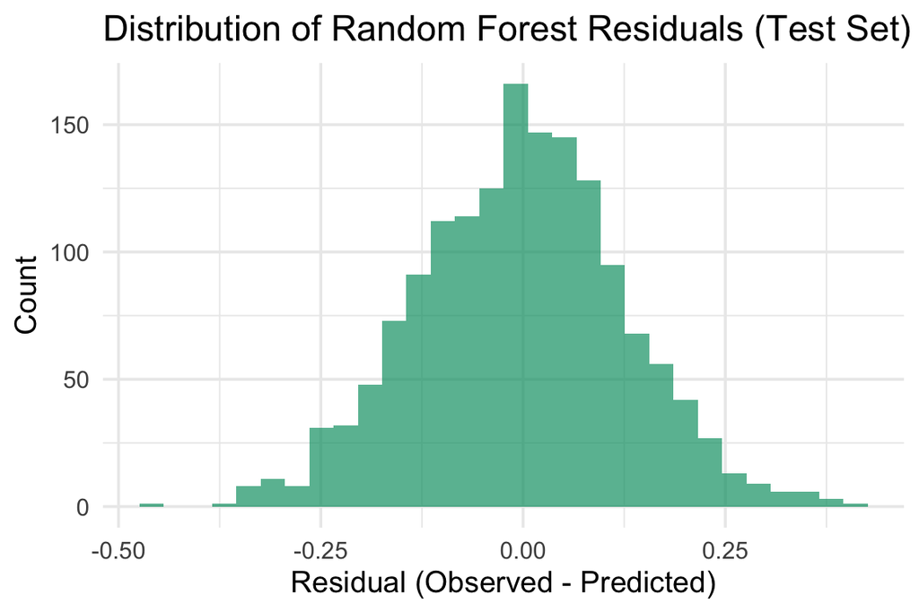

```r
# 5. Residual Distribution (Test set)

p3 <- ggplot(test, aes(x = rf_resid)) +
  geom_histogram(bins = 30, fill = "#009E73", alpha = 0.7) +
  labs(
    title = "Distribution of Random Forest Residuals (Test Set)",
    x = "Residual (Observed - Predicted)",
    y = "Count"
  ) +
  theme_minimal(base_size = 14)

print(p3)
```

Residuals form a near-normal distribution centered around zero, suggesting that the Random Forest does not systematically overpredict or underpredict temperature anomalies. Most residuals fall within ±0.15°C, which is reasonable for global climate-economic data. This distribution indicates well-behaved errors and supports the model’s reliability. Together with the other evaluation checks, this reinforces that the Random Forest is an effective tool for capturing the complex interplay between emissions, demographics, energy transition, and temperature outcomes.